# Risk Factor Analysis

## Outcome Variable

**Outcome Variable:** ever_stunted

## Predictor Variables

**Intervention Variable:** mage

**Adjustment Set:**

- arm
- meducyrs
- feducyrs
- W_mhtcm
- single
- delta_meducyrs
- delta_feducyrs
- delta_W_mhtcm
- delta_single

## Stratifying Variables

The analysis was stratified on these variable(s):

- agecat
- studyid
- country

## Data Summary

| agecat | studyid | country | mage | ever_stunted | n_cell | n |
| --- | --- | --- | --- | --- | --- | --- |
| 0-6 months | ki0047075b-MAL-ED | BANGLADESH | <20 | 0 | 28 | 265 |
| 0-6 months | ki0047075b-MAL-ED | BANGLADESH | <20 | 1 | 9 | 265 |
| 0-6 months | ki0047075b-MAL-ED | BANGLADESH | [20-25) | 0 | 74 | 265 |
| 0-6 months | ki0047075b-MAL-ED | BANGLADESH | [20-25) | 1 | 15 | 265 |
| 0-6 months | ki0047075b-MAL-ED | BANGLADESH | [25-30) | 0 | 78 | 265 |
| 0-6 months | ki0047075b-MAL-ED | BANGLADESH | [25-30) | 1 | 15 | 265 |
| 0-6 months | ki0047075b-MAL-ED | BANGLADESH | >=30 | 0 | 37 | 265 |
| 0-6 months | ki0047075b-MAL-ED | BANGLADESH | >=30 | 1 | 9 | 265 |
| 0-6 months | ki0047075b-MAL-ED | BRAZIL | <20 | 0 | 41 | 233 |
| 0-6 months | ki0047075b-MAL-ED | BRAZIL | <20 | 1 | 2 | 233 |
| 0-6 months | ki0047075b-MAL-ED | BRAZIL | [20-25) | 0 | 65 | 233 |
| 0-6 months | ki0047075b-MAL-ED | BRAZIL | [20-25) | 1 | 9 | 233 |
| 0-6 months | ki0047075b-MAL-ED | BRAZIL | [25-30) | 0 | 55 | 233 |
| 0-6 months | ki0047075b-MAL-ED | BRAZIL | [25-30) | 1 | 10 | 233 |
| 0-6 months | ki0047075b-MAL-ED | BRAZIL | >=30 | 0 | 47 | 233 |
| 0-6 months | ki0047075b-MAL-ED | BRAZIL | >=30 | 1 | 4 | 233 |
| 0-6 months | ki0047075b-MAL-ED | INDIA | <20 | 0 | 26 | 249 |
| 0-6 months | ki0047075b-MAL-ED | INDIA | <20 | 1 | 8 | 249 |
| 0-6 months | ki0047075b-MAL-ED | INDIA | [20-25) | 0 | 92 | 249 |
| 0-6 months | ki0047075b-MAL-ED | INDIA | [20-25) | 1 | 19 | 249 |
| 0-6 months | ki0047075b-MAL-ED | INDIA | [25-30) | 0 | 70 | 249 |
| 0-6 months | ki0047075b-MAL-ED | INDIA | [25-30) | 1 | 13 | 249 |
| 0-6 months | ki0047075b-MAL-ED | INDIA | >=30 | 0 | 20 | 249 |
| 0-6 months | ki0047075b-MAL-ED | INDIA | >=30 | 1 | 1 | 249 |
| 0-6 months | ki0047075b-MAL-ED | NEPAL | <20 | 0 | 3 | 240 |
| 0-6 months | ki0047075b-MAL-ED | NEPAL | <20 | 1 | 2 | 240 |
| 0-6 months | ki0047075b-MAL-ED | NEPAL | [20-25) | 0 | 51 | 240 |
| 0-6 months | ki0047075b-MAL-ED | NEPAL | [20-25) | 1 | 10 | 240 |
| 0-6 months | ki0047075b-MAL-ED | NEPAL | [25-30) | 0 | 116 | 240 |
| 0-6 months | ki0047075b-MAL-ED | NEPAL | [25-30) | 1 | 12 | 240 |

[output cut: 604 more lines]

The following strata were considered:

- agecat: 0-24 months, studyid: ki0047075b-MAL-ED, country: BANGLADESH
- agecat: 0-24 months, studyid: ki0047075b-MAL-ED, country: BRAZIL
- agecat: 0-24 months, studyid: ki0047075b-MAL-ED, country: INDIA
- agecat: 0-24 months, studyid: ki0047075b-MAL-ED, country: NEPAL
- agecat: 0-24 months, studyid: ki0047075b-MAL-ED, country: PERU
- agecat: 0-24 months, studyid: ki0047075b-MAL-ED, country: SOUTH AFRICA
- agecat: 0-24 months, studyid: ki0047075b-MAL-ED, country: TANZANIA, UNITED REPUBLIC OF
- agecat: 0-24 months, studyid: ki1000108-CMC-V-BCS-2002, country: INDIA
- agecat: 0-24 months, studyid: ki1000108-IRC, country: INDIA
- agecat: 0-24 months, studyid: ki1000109-EE, country: PAKISTAN
- agecat: 0-24 months, studyid: ki1000304b-SAS-CompFeed, country: INDIA
- agecat: 0-24 months, studyid: ki1000304b-SAS-FoodSuppl, country: INDIA
- agecat: 0-24 months, studyid: ki1017093-NIH-Birth, country: BANGLADESH
- agecat: 0-24 months, studyid: ki1017093b-PROVIDE, country: BANGLADESH
- agecat: 0-24 months, studyid: ki1017093c-NIH-Crypto, country: BANGLADESH
- agecat: 0-24 months, studyid: ki1066203-TanzaniaChild2, country: TANZANIA, UNITED REPUBLIC OF
- agecat: 0-24 months, studyid: ki1101329-Keneba, country: GAMBIA
- agecat: 0-24 months, studyid: ki1112895-Guatemala BSC, country: GUATEMALA
- agecat: 0-24 months, studyid: ki1112895-iLiNS-Zinc, country: BURKINA FASO
- agecat: 0-24 months, studyid: ki1113344-GMS-Nepal, country: NEPAL
- agecat: 0-24 months, studyid: ki1119695-PROBIT, country: BELARUS
- agecat: 0-24 months, studyid: ki1126311-ZVITAMBO, country: ZIMBABWE
- agecat: 0-24 months, studyid: ki1135781-COHORTS, country: GUATEMALA
- agecat: 0-24 months, studyid: ki1135781-COHORTS, country: INDIA
- agecat: 0-24 months, studyid: ki1135781-COHORTS, country: PHILIPPINES
- agecat: 0-24 months, studyid: ki1148112-LCNI-5, country: MALAWI
- agecat: 0-24 months, studyid: kiGH5241-JiVitA-3, country: BANGLADESH
- agecat: 0-6 months, studyid: ki0047075b-MAL-ED, country: BANGLADESH
- agecat: 0-6 months, studyid: ki0047075b-MAL-ED, country: BRAZIL
- agecat: 0-6 months, studyid: ki0047075b-MAL-ED, country: INDIA
- agecat: 0-6 months, studyid: ki0047075b-MAL-ED, country: NEPAL
- agecat: 0-6 months, studyid: ki0047075b-MAL-ED, country: PERU
- agecat: 0-6 months, studyid: ki0047075b-MAL-ED, country: SOUTH AFRICA
- agecat: 0-6 months, studyid: ki0047075b-MAL-ED, country: TANZANIA, UNITED REPUBLIC OF
- agecat: 0-6 months, studyid: ki1000108-CMC-V-BCS-2002, country: INDIA
- agecat: 0-6 months, studyid: ki1000108-IRC, country: INDIA
- agecat: 0-6 months, studyid: ki1000109-EE, country: PAKISTAN
- agecat: 0-6 months, studyid: ki1000304b-SAS-CompFeed, country: INDIA
- agecat: 0-6 months, studyid: ki1000304b-SAS-FoodSuppl, country: INDIA
- agecat: 0-6 months, studyid: ki1017093-NIH-Birth, country: BANGLADESH
- agecat: 0-6 months, studyid: ki1017093b-PROVIDE, country: BANGLADESH
- agecat: 0-6 months, studyid: ki1017093c-NIH-Crypto, country: BANGLADESH
- agecat: 0-6 months, studyid: ki1066203-TanzaniaChild2, country: TANZANIA, UNITED REPUBLIC OF
- agecat: 0-6 months, studyid: ki1101329-Keneba, country: GAMBIA
- agecat: 0-6 months, studyid: ki1112895-Guatemala BSC, country: GUATEMALA
- agecat: 0-6 months, studyid: ki1113344-GMS-Nepal, country: NEPAL
- agecat: 0-6 months, studyid: ki1119695-PROBIT, country: BELARUS
- agecat: 0-6 months, studyid: ki1126311-ZVITAMBO, country: ZIMBABWE
- agecat: 0-6 months, studyid: ki1135781-COHORTS, country: GUATEMALA
- agecat: 0-6 months, studyid: ki1135781-COHORTS, country: INDIA
- agecat: 0-6 months, studyid: ki1135781-COHORTS, country: PHILIPPINES
- agecat: 0-6 months, studyid: ki1148112-LCNI-5, country: MALAWI
- agecat: 0-6 months, studyid: kiGH5241-JiVitA-3, country: BANGLADESH
- agecat: 6-24 months, studyid: ki0047075b-MAL-ED, country: BANGLADESH
- agecat: 6-24 months, studyid: ki0047075b-MAL-ED, country: BRAZIL
- agecat: 6-24 months, studyid: ki0047075b-MAL-ED, country: INDIA
- agecat: 6-24 months, studyid: ki0047075b-MAL-ED, country: NEPAL
- agecat: 6-24 months, studyid: ki0047075b-MAL-ED, country: PERU
- agecat: 6-24 months, studyid: ki0047075b-MAL-ED, country: SOUTH AFRICA
- agecat: 6-24 months, studyid: ki0047075b-MAL-ED, country: TANZANIA, UNITED REPUBLIC OF
- agecat: 6-24 months, studyid: ki1000108-CMC-V-BCS-2002, country: INDIA
- agecat: 6-24 months, studyid: ki1000108-IRC, country: INDIA
- agecat: 6-24 months, studyid: ki1000109-EE, country: PAKISTAN
- agecat: 6-24 months, studyid: ki1000304b-SAS-CompFeed, country: INDIA
- agecat: 6-24 months, studyid: ki1000304b-SAS-FoodSuppl, country: INDIA
- agecat: 6-24 months, studyid: ki1017093-NIH-Birth, country: BANGLADESH
- agecat: 6-24 months, studyid: ki1017093b-PROVIDE, country: BANGLADESH
- agecat: 6-24 months, studyid: ki1017093c-NIH-Crypto, country: BANGLADESH
- agecat: 6-24 months, studyid: ki1066203-TanzaniaChild2, country: TANZANIA, UNITED REPUBLIC OF
- agecat: 6-24 months, studyid: ki1101329-Keneba, country: GAMBIA
- agecat: 6-24 months, studyid: ki1112895-Guatemala BSC, country: GUATEMALA
- agecat: 6-24 months, studyid: ki1112895-iLiNS-Zinc, country: BURKINA FASO
- agecat: 6-24 months, studyid: ki1113344-GMS-Nepal, country: NEPAL
- agecat: 6-24 months, studyid: ki1119695-PROBIT, country: BELARUS
- agecat: 6-24 months, studyid: ki1126311-ZVITAMBO, country: ZIMBABWE
- agecat: 6-24 months, studyid: ki1135781-COHORTS, country: GUATEMALA
- agecat: 6-24 months, studyid: ki1135781-COHORTS, country: INDIA
- agecat: 6-24 months, studyid: ki1135781-COHORTS, country: PHILIPPINES
- agecat: 6-24 months, studyid: ki1148112-LCNI-5, country: MALAWI
- agecat: 6-24 months, studyid: kiGH5241-JiVitA-3, country: BANGLADESH

## Methods Detail

We’re interested in the causal parameters $E[Y_a]$ for all values of $a \in \mathcal{A}$. These parameters represent the mean outcome if, possibly contrary to fact, we intervened to set all units to have $A=a$. Under the randomization and positivity assumptions, these are identified by the statistical parameters $\psi_a=E_W[E_{Y|A,W}(Y|A=a,W)]$. In addition, we’re interested in the mean of $Y$, $E[Y]$ under no intervention (the observed mean). We will estimate these parameters by using SuperLearner to fit the relevant likelihood factors – $E_{Y|A,W}(Y|A=a,W)$ and $p(A=a|W)$, and then updating our likelihood fit using a joint TMLE.

For unadjusted analyses ($W=\{\}$), initial likelihoods were estimated using Lrnr_glm to estimate the simple $E(Y|A)$ and Lrnr_mean to estimate $p(A)$. For adjusted analyses, a small library containing Lrnr_glmnet, Lrnr_xgboost, and Lrnr_mean was used.

Having estimated these parameters, we will then use the delta method to estimate relative risks and attributable risks relative to a prespecified baseline level of $A$.

```
##          ever_stunted
## mage         0
##   <20      290
##   [20-25) 1389
##   [25-30) 1349
##   >=30     952
```

# Results Detail

## Results Plots

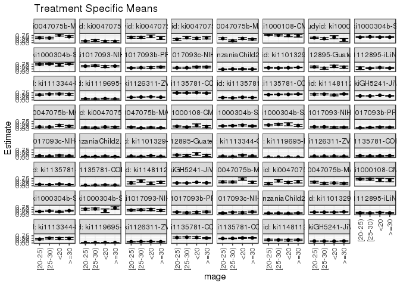

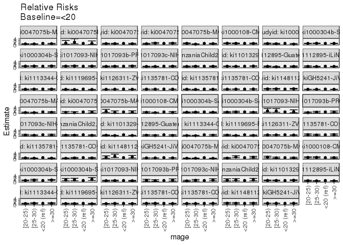

[figure not shown]

[figure not shown]

## Results Table

### Parameter: TSM

| agecat | studyid | country | intervention_level | baseline_level | estimate | ci_lower | ci_upper |
| --- | --- | --- | --- | --- | --- | --- | --- |
| 0-24 months | ki0047075b-MAL-ED | BANGLADESH | <20 | NA | 0.7888041 | 0.6905596 | 0.8870486 |
| 0-24 months | ki0047075b-MAL-ED | BANGLADESH | [20-25) | NA | 0.5104577 | 0.4225185 | 0.5983969 |
| 0-24 months | ki0047075b-MAL-ED | BANGLADESH | [25-30) | NA | 0.4814318 | 0.3954406 | 0.5674230 |
| 0-24 months | ki0047075b-MAL-ED | BANGLADESH | >=30 | NA | 0.6266591 | 0.5240707 | 0.7292474 |
| 0-24 months | ki0047075b-MAL-ED | BRAZIL | <20 | NA | 0.1282007 | 0.0338100 | 0.2225913 |
| 0-24 months | ki0047075b-MAL-ED | BRAZIL | [20-25) | NA | 0.1542232 | 0.0740000 | 0.2344464 |
| 0-24 months | ki0047075b-MAL-ED | BRAZIL | [25-30) | NA | 0.2255090 | 0.1263588 | 0.3246592 |
| 0-24 months | ki0047075b-MAL-ED | BRAZIL | >=30 | NA | 0.1247370 | 0.0387563 | 0.2107177 |
| 0-24 months | ki0047075b-MAL-ED | INDIA | <20 | NA | 0.6600981 | 0.5152616 | 0.8049347 |
| 0-24 months | ki0047075b-MAL-ED | INDIA | [20-25) | NA | 0.5507650 | 0.4608559 | 0.6406741 |
| 0-24 months | ki0047075b-MAL-ED | INDIA | [25-30) | NA | 0.5521706 | 0.4511406 | 0.6532006 |
| 0-24 months | ki0047075b-MAL-ED | INDIA | >=30 | NA | 0.4925290 | 0.3427078 | 0.6423502 |
| 0-24 months | ki0047075b-MAL-ED | PERU | <20 | NA | 0.4566104 | 0.3512181 | 0.5620027 |
| 0-24 months | ki0047075b-MAL-ED | PERU | [20-25) | NA | 0.3468939 | 0.2485641 | 0.4452237 |
| 0-24 months | ki0047075b-MAL-ED | PERU | [25-30) | NA | 0.5250916 | 0.4038082 | 0.6463750 |
| 0-24 months | ki0047075b-MAL-ED | PERU | >=30 | NA | 0.5022424 | 0.3847781 | 0.6197067 |
| 0-24 months | ki0047075b-MAL-ED | SOUTH AFRICA | <20 | NA | 0.4362581 | 0.3405167 | 0.5319995 |
| 0-24 months | ki0047075b-MAL-ED | SOUTH AFRICA | [20-25) | NA | 0.4392410 | 0.3595027 | 0.5189793 |
| 0-24 months | ki0047075b-MAL-ED | SOUTH AFRICA | [25-30) | NA | 0.2073073 | 0.1242576 | 0.2903570 |
| 0-24 months | ki0047075b-MAL-ED | SOUTH AFRICA | >=30 | NA | 0.3559178 | 0.2796637 | 0.4321720 |
| 0-24 months | ki1000108-CMC-V-BCS-2002 | INDIA | <20 | NA | 0.7647059 | 0.6219335 | 0.9074783 |
| 0-24 months | ki1000108-CMC-V-BCS-2002 | INDIA | [20-25) | NA | 0.8288770 | 0.7748253 | 0.8829287 |
| 0-24 months | ki1000108-CMC-V-BCS-2002 | INDIA | [25-30) | NA | 0.7798165 | 0.7019221 | 0.8577109 |
| 0-24 months | ki1000108-CMC-V-BCS-2002 | INDIA | >=30 | NA | 0.7209302 | 0.5866847 | 0.8551758 |
| 0-24 months | ki1000108-IRC | INDIA | <20 | NA | 0.5675676 | 0.4077423 | 0.7273928 |
| 0-24 months | ki1000108-IRC | INDIA | [20-25) | NA | 0.5113122 | 0.4453279 | 0.5772966 |
| 0-24 months | ki1000108-IRC | INDIA | [25-30) | NA | 0.4308943 | 0.3432734 | 0.5185152 |
| 0-24 months | ki1000108-IRC | INDIA | >=30 | NA | 0.2758621 | 0.1129940 | 0.4387302 |
| 0-24 months | ki1000304b-SAS-CompFeed | INDIA | <20 | NA | 0.5758478 | 0.5342077 | 0.6174878 |
| 0-24 months | ki1000304b-SAS-CompFeed | INDIA | [20-25) | NA | 0.5705285 | 0.5231099 | 0.6179471 |

[output cut: 222 more lines]

### Parameter: E(Y)

| agecat | studyid | country | intervention_level | baseline_level | estimate | ci_lower | ci_upper |
| --- | --- | --- | --- | --- | --- | --- | --- |
| 0-24 months | ki0047075b-MAL-ED | BANGLADESH | NA | NA | 0.5056604 | 0.4453505 | 0.5659702 |
| 0-24 months | ki0047075b-MAL-ED | BRAZIL | NA | NA | 0.1545064 | 0.1079979 | 0.2010150 |
| 0-24 months | ki0047075b-MAL-ED | INDIA | NA | NA | 0.4979920 | 0.4357636 | 0.5602204 |
| 0-24 months | ki0047075b-MAL-ED | PERU | NA | NA | 0.4488449 | 0.3927492 | 0.5049406 |
| 0-24 months | ki0047075b-MAL-ED | SOUTH AFRICA | NA | NA | 0.3853503 | 0.3314343 | 0.4392663 |
| 0-24 months | ki1000108-CMC-V-BCS-2002 | INDIA | NA | NA | 0.7962466 | 0.7553156 | 0.8371777 |
| 0-24 months | ki1000108-IRC | INDIA | NA | NA | 0.4756098 | 0.4272105 | 0.5240091 |
| 0-24 months | ki1000304b-SAS-CompFeed | INDIA | NA | NA | 0.5942596 | 0.5539147 | 0.6346046 |
| 0-24 months | ki1000304b-SAS-FoodSuppl | INDIA | NA | NA | 0.7464115 | 0.7046540 | 0.7881689 |
| 0-24 months | ki1017093-NIH-Birth | BANGLADESH | NA | NA | 0.5454545 | 0.5064488 | 0.5844603 |
| 0-24 months | ki1017093b-PROVIDE | BANGLADESH | NA | NA | 0.3757143 | 0.3398113 | 0.4116172 |
| 0-24 months | ki1017093c-NIH-Crypto | BANGLADESH | NA | NA | 0.3878628 | 0.3531521 | 0.4225735 |
| 0-24 months | ki1066203-TanzaniaChild2 | TANZANIA, UNITED REPUBLIC OF | NA | NA | 0.2251684 | 0.2083697 | 0.2419670 |
| 0-24 months | ki1101329-Keneba | GAMBIA | NA | NA | 0.3767051 | 0.3589402 | 0.3944701 |
| 0-24 months | ki1112895-Guatemala BSC | GUATEMALA | NA | NA | 0.4733096 | 0.4148280 | 0.5317912 |
| 0-24 months | ki1112895-iLiNS-Zinc | BURKINA FASO | NA | NA | 0.3314448 | 0.2804289 | 0.3824606 |
| 0-24 months | ki1113344-GMS-Nepal | NEPAL | NA | NA | 0.5780731 | 0.5385891 | 0.6175571 |
| 0-24 months | ki1119695-PROBIT | BELARUS | NA | NA | 0.1006096 | 0.0848963 | 0.1163228 |
| 0-24 months | ki1126311-ZVITAMBO | ZIMBABWE | NA | NA | 0.2924535 | 0.2849270 | 0.2999800 |
| 0-24 months | ki1135781-COHORTS | GUATEMALA | NA | NA | 0.7213235 | 0.6974864 | 0.7451606 |
| 0-24 months | ki1135781-COHORTS | INDIA | NA | NA | 0.2375306 | 0.2260863 | 0.2489749 |
| 0-24 months | ki1135781-COHORTS | PHILIPPINES | NA | NA | 0.5716154 | 0.5540738 | 0.5891570 |
| 0-24 months | ki1148112-LCNI-5 | MALAWI | NA | NA | 0.5820896 | 0.5447154 | 0.6194637 |
| 0-24 months | kiGH5241-JiVitA-3 | BANGLADESH | NA | NA | 0.4437098 | 0.4361997 | 0.4512200 |
| 0-6 months | ki0047075b-MAL-ED | BANGLADESH | NA | NA | 0.1811321 | 0.1346751 | 0.2275890 |
| 0-6 months | ki0047075b-MAL-ED | PERU | NA | NA | 0.1221122 | 0.0851852 | 0.1590392 |
| 0-6 months | ki0047075b-MAL-ED | SOUTH AFRICA | NA | NA | 0.1082803 | 0.0738560 | 0.1427045 |
| 0-6 months | ki1000108-CMC-V-BCS-2002 | INDIA | NA | NA | 0.2065217 | 0.1651060 | 0.2479375 |
| 0-6 months | ki1000304b-SAS-CompFeed | INDIA | NA | NA | 0.2882353 | 0.2618269 | 0.3146436 |
| 0-6 months | ki1000304b-SAS-FoodSuppl | INDIA | NA | NA | 0.3822115 | 0.3354600 | 0.4289631 |
| 0-6 months | ki1017093-NIH-Birth | BANGLADESH | NA | NA | 0.1578947 | 0.1293302 | 0.1864593 |
| 0-6 months | ki1017093b-PROVIDE | BANGLADESH | NA | NA | 0.0942857 | 0.0726222 | 0.1159492 |
| 0-6 months | ki1017093c-NIH-Crypto | BANGLADESH | NA | NA | 0.1385224 | 0.1139141 | 0.1631308 |
| 0-6 months | ki1066203-TanzaniaChild2 | TANZANIA, UNITED REPUBLIC OF | NA | NA | 0.0669192 | 0.0568695 | 0.0769688 |
| 0-6 months | ki1101329-Keneba | GAMBIA | NA | NA | 0.0929185 | 0.0814039 | 0.1044332 |
| 0-6 months | ki1112895-Guatemala BSC | GUATEMALA | NA | NA | 0.2386364 | 0.1871213 | 0.2901515 |
| 0-6 months | ki1113344-GMS-Nepal | NEPAL | NA | NA | 0.1112957 | 0.0861520 | 0.1364394 |
| 0-6 months | ki1119695-PROBIT | BELARUS | NA | NA | 0.0090570 | 0.0059070 | 0.0122070 |
| 0-6 months | ki1126311-ZVITAMBO | ZIMBABWE | NA | NA | 0.1051317 | 0.1000527 | 0.1102107 |
| 0-6 months | ki1135781-COHORTS | GUATEMALA | NA | NA | 0.1347388 | 0.1144687 | 0.1550088 |
| 0-6 months | ki1135781-COHORTS | INDIA | NA | NA | 0.1217137 | 0.1127702 | 0.1306572 |
| 0-6 months | ki1135781-COHORTS | PHILIPPINES | NA | NA | 0.0614781 | 0.0529631 | 0.0699931 |
| 0-6 months | ki1148112-LCNI-5 | MALAWI | NA | NA | 0.3545455 | 0.2911884 | 0.4179025 |
| 0-6 months | kiGH5241-JiVitA-3 | BANGLADESH | NA | NA | 0.3218454 | 0.3150991 | 0.3285918 |
| 6-24 months | ki0047075b-MAL-ED | BANGLADESH | NA | NA | 0.3743590 | 0.3062579 | 0.4424600 |
| 6-24 months | ki0047075b-MAL-ED | PERU | NA | NA | 0.3275109 | 0.2665942 | 0.3884276 |
| 6-24 months | ki0047075b-MAL-ED | SOUTH AFRICA | NA | NA | 0.2633929 | 0.2055812 | 0.3212045 |
| 6-24 months | ki1000108-CMC-V-BCS-2002 | INDIA | NA | NA | 0.6631944 | 0.6085159 | 0.7178730 |
| 6-24 months | ki1000304b-SAS-CompFeed | INDIA | NA | NA | 0.3184647 | 0.2882909 | 0.3486385 |
| 6-24 months | ki1000304b-SAS-FoodSuppl | INDIA | NA | NA | 0.5619469 | 0.4971181 | 0.6267757 |
| 6-24 months | ki1017093-NIH-Birth | BANGLADESH | NA | NA | 0.4510740 | 0.4033715 | 0.4987764 |
| 6-24 months | ki1017093b-PROVIDE | BANGLADESH | NA | NA | 0.2394366 | 0.2018814 | 0.2769918 |
| 6-24 months | ki1017093c-NIH-Crypto | BANGLADESH | NA | NA | 0.1887097 | 0.1578857 | 0.2195336 |
| 6-24 months | ki1066203-TanzaniaChild2 | TANZANIA, UNITED REPUBLIC OF | NA | NA | 0.1335878 | 0.1180133 | 0.1491622 |
| 6-24 months | ki1101329-Keneba | GAMBIA | NA | NA | 0.2387484 | 0.2214455 | 0.2560513 |
| 6-24 months | ki1112895-iLiNS-Zinc | BURKINA FASO | NA | NA | 0.1520334 | 0.1259980 | 0.1780689 |
| 6-24 months | ki1113344-GMS-Nepal | NEPAL | NA | NA | 0.4479167 | 0.4033837 | 0.4924496 |
| 6-24 months | ki1119695-PROBIT | BELARUS | NA | NA | 0.0380298 | 0.0285924 | 0.0474672 |
| 6-24 months | ki1126311-ZVITAMBO | ZIMBABWE | NA | NA | 0.1359725 | 0.1290044 | 0.1429405 |
| 6-24 months | ki1135781-COHORTS | GUATEMALA | NA | NA | 0.5625000 | 0.5235458 | 0.6014542 |
| 6-24 months | ki1135781-COHORTS | PHILIPPINES | NA | NA | 0.4901079 | 0.4693271 | 0.5108888 |
| 6-24 months | ki1148112-LCNI-5 | MALAWI | NA | NA | 0.3121019 | 0.2702120 | 0.3539918 |
| 6-24 months | kiGH5241-JiVitA-3 | BANGLADESH | NA | NA | 0.1970825 | 0.1890251 | 0.2051399 |

### Parameter: RR

| agecat | studyid | country | intervention_level | baseline_level | estimate | ci_lower | ci_upper |
| --- | --- | --- | --- | --- | --- | --- | --- |
| 0-24 months | ki0047075b-MAL-ED | BANGLADESH | <20 | <20 | 1.0000000 | 1.0000000 | 1.0000000 |
| 0-24 months | ki0047075b-MAL-ED | BANGLADESH | [20-25) | <20 | 0.6471285 | 0.5249233 | 0.7977839 |
| 0-24 months | ki0047075b-MAL-ED | BANGLADESH | [25-30) | <20 | 0.6103312 | 0.4924498 | 0.7564308 |
| 0-24 months | ki0047075b-MAL-ED | BANGLADESH | >=30 | <20 | 0.7944419 | 0.6485745 | 0.9731156 |
| 0-24 months | ki0047075b-MAL-ED | BRAZIL | <20 | <20 | 1.0000000 | 1.0000000 | 1.0000000 |
| 0-24 months | ki0047075b-MAL-ED | BRAZIL | [20-25) | <20 | 1.2029833 | 0.4882137 | 2.9642119 |
| 0-24 months | ki0047075b-MAL-ED | BRAZIL | [25-30) | <20 | 1.7590316 | 0.7463848 | 4.1455722 |
| 0-24 months | ki0047075b-MAL-ED | BRAZIL | >=30 | <20 | 0.9729827 | 0.3547491 | 2.6686331 |
| 0-24 months | ki0047075b-MAL-ED | INDIA | <20 | <20 | 1.0000000 | 1.0000000 | 1.0000000 |
| 0-24 months | ki0047075b-MAL-ED | INDIA | [20-25) | <20 | 0.8343684 | 0.6350078 | 1.0963182 |
| 0-24 months | ki0047075b-MAL-ED | INDIA | [25-30) | <20 | 0.8364978 | 0.6288770 | 1.1126636 |
| 0-24 months | ki0047075b-MAL-ED | INDIA | >=30 | <20 | 0.7461451 | 0.5128948 | 1.0854712 |
| 0-24 months | ki0047075b-MAL-ED | PERU | <20 | <20 | 1.0000000 | 1.0000000 | 1.0000000 |
| 0-24 months | ki0047075b-MAL-ED | PERU | [20-25) | <20 | 0.7597154 | 0.5281954 | 1.0927158 |
| 0-24 months | ki0047075b-MAL-ED | PERU | [25-30) | <20 | 1.1499773 | 0.8310694 | 1.5912603 |
| 0-24 months | ki0047075b-MAL-ED | PERU | >=30 | <20 | 1.0999365 | 0.7934326 | 1.5248432 |
| 0-24 months | ki0047075b-MAL-ED | SOUTH AFRICA | <20 | <20 | 1.0000000 | 1.0000000 | 1.0000000 |
| 0-24 months | ki0047075b-MAL-ED | SOUTH AFRICA | [20-25) | <20 | 1.0068376 | 0.7620464 | 1.3302628 |
| 0-24 months | ki0047075b-MAL-ED | SOUTH AFRICA | [25-30) | <20 | 0.4751941 | 0.3016417 | 0.7486016 |
| 0-24 months | ki0047075b-MAL-ED | SOUTH AFRICA | >=30 | <20 | 0.8158424 | 0.6042985 | 1.1014404 |
| 0-24 months | ki1000108-CMC-V-BCS-2002 | INDIA | <20 | <20 | 1.0000000 | 1.0000000 | 1.0000000 |
| 0-24 months | ki1000108-CMC-V-BCS-2002 | INDIA | [20-25) | <20 | 1.0839161 | 0.8894228 | 1.3209399 |
| 0-24 months | ki1000108-CMC-V-BCS-2002 | INDIA | [25-30) | <20 | 1.0197601 | 0.8251613 | 1.2602513 |
| 0-24 months | ki1000108-CMC-V-BCS-2002 | INDIA | >=30 | <20 | 0.9427549 | 0.7242352 | 1.2272075 |
| 0-24 months | ki1000108-IRC | INDIA | <20 | <20 | 1.0000000 | 1.0000000 | 1.0000000 |
| 0-24 months | ki1000108-IRC | INDIA | [20-25) | <20 | 0.9008834 | 0.6609097 | 1.2279908 |
| 0-24 months | ki1000108-IRC | INDIA | [25-30) | <20 | 0.7591947 | 0.5364193 | 1.0744891 |
| 0-24 months | ki1000108-IRC | INDIA | >=30 | <20 | 0.4860427 | 0.2526948 | 0.9348729 |
| 0-24 months | ki1000304b-SAS-CompFeed | INDIA | <20 | <20 | 1.0000000 | 1.0000000 | 1.0000000 |
| 0-24 months | ki1000304b-SAS-CompFeed | INDIA | [20-25) | <20 | 0.9907627 | 0.8891852 | 1.1039440 |

[output cut: 222 more lines]

### Parameter: PAR

| agecat | studyid | country | intervention_level | baseline_level | estimate | ci_lower | ci_upper |
| --- | --- | --- | --- | --- | --- | --- | --- |
| 0-24 months | ki0047075b-MAL-ED | BANGLADESH | <20 | NA | -0.2831437 | -0.3779914 | -0.1882961 |
| 0-24 months | ki0047075b-MAL-ED | BRAZIL | <20 | NA | 0.0263058 | -0.0616073 | 0.1142188 |
| 0-24 months | ki0047075b-MAL-ED | INDIA | <20 | NA | -0.1621062 | -0.2977089 | -0.0265034 |
| 0-24 months | ki0047075b-MAL-ED | PERU | <20 | NA | -0.0077655 | -0.0970596 | 0.0815286 |
| 0-24 months | ki0047075b-MAL-ED | SOUTH AFRICA | <20 | NA | -0.0509078 | -0.1391238 | 0.0373083 |
| 0-24 months | ki1000108-CMC-V-BCS-2002 | INDIA | <20 | NA | 0.0315408 | -0.1038963 | 0.1669778 |
| 0-24 months | ki1000108-IRC | INDIA | <20 | NA | -0.0919578 | -0.2445232 | 0.0606076 |
| 0-24 months | ki1000304b-SAS-CompFeed | INDIA | <20 | NA | 0.0184118 | -0.0356347 | 0.0724584 |
| 0-24 months | ki1000304b-SAS-FoodSuppl | INDIA | <20 | NA | 0.0706967 | -0.0580269 | 0.1994203 |
| 0-24 months | ki1017093-NIH-Birth | BANGLADESH | <20 | NA | 0.0466815 | -0.0565670 | 0.1499300 |
| 0-24 months | ki1017093b-PROVIDE | BANGLADESH | <20 | NA | -0.0113038 | -0.1002687 | 0.0776612 |
| 0-24 months | ki1017093c-NIH-Crypto | BANGLADESH | <20 | NA | -0.0497285 | -0.1233713 | 0.0239144 |
| 0-24 months | ki1066203-TanzaniaChild2 | TANZANIA, UNITED REPUBLIC OF | <20 | NA | -0.0176965 | -0.0763133 | 0.0409203 |
| 0-24 months | ki1101329-Keneba | GAMBIA | <20 | NA | 0.0095099 | -0.0333494 | 0.0523691 |
| 0-24 months | ki1112895-Guatemala BSC | GUATEMALA | <20 | NA | -0.0416735 | -0.1576397 | 0.0742927 |
| 0-24 months | ki1112895-iLiNS-Zinc | BURKINA FASO | <20 | NA | -0.0541745 | -0.1191744 | 0.0108253 |
| 0-24 months | ki1113344-GMS-Nepal | NEPAL | <20 | NA | -0.0323502 | -0.1094153 | 0.0447148 |
| 0-24 months | ki1119695-PROBIT | BELARUS | <20 | NA | -0.0247315 | -0.0438513 | -0.0056116 |
| 0-24 months | ki1126311-ZVITAMBO | ZIMBABWE | <20 | NA | -0.0326936 | -0.0495546 | -0.0158325 |
| 0-24 months | ki1135781-COHORTS | GUATEMALA | <20 | NA | -0.0382318 | -0.0845155 | 0.0080519 |
| 0-24 months | ki1135781-COHORTS | INDIA | <20 | NA | -0.0350376 | -0.0722593 | 0.0021842 |
| 0-24 months | ki1135781-COHORTS | PHILIPPINES | <20 | NA | -0.0041229 | -0.0478725 | 0.0396266 |
| 0-24 months | ki1148112-LCNI-5 | MALAWI | <20 | NA | 0.0687953 | -0.0128970 | 0.1504876 |
| 0-24 months | kiGH5241-JiVitA-3 | BANGLADESH | <20 | NA | -0.0362929 | -0.0429072 | -0.0296786 |
| 0-6 months | ki0047075b-MAL-ED | BANGLADESH | <20 | NA | -0.1431754 | -0.2420220 | -0.0443288 |
| 0-6 months | ki0047075b-MAL-ED | PERU | <20 | NA | -0.0465625 | -0.1121956 | 0.0190706 |
| 0-6 months | ki0047075b-MAL-ED | SOUTH AFRICA | <20 | NA | 0.0086124 | -0.0446439 | 0.0618687 |
| 0-6 months | ki1000108-CMC-V-BCS-2002 | INDIA | <20 | NA | -0.1170077 | -0.2650903 | 0.0310750 |
| 0-6 months | ki1000304b-SAS-CompFeed | INDIA | <20 | NA | -0.0562739 | -0.1361204 | 0.0235726 |
| 0-6 months | ki1000304b-SAS-FoodSuppl | INDIA | <20 | NA | -0.0559918 | -0.2077960 | 0.0958124 |
| 0-6 months | ki1017093-NIH-Birth | BANGLADESH | <20 | NA | 0.0489721 | -0.0195805 | 0.1175248 |
| 0-6 months | ki1017093b-PROVIDE | BANGLADESH | <20 | NA | -0.0417330 | -0.0977987 | 0.0143327 |
| 0-6 months | ki1017093c-NIH-Crypto | BANGLADESH | <20 | NA | -0.0333523 | -0.0880038 | 0.0212992 |
| 0-6 months | ki1066203-TanzaniaChild2 | TANZANIA, UNITED REPUBLIC OF | <20 | NA | -0.0315944 | -0.0725753 | 0.0093865 |
| 0-6 months | ki1101329-Keneba | GAMBIA | <20 | NA | -0.0597464 | -0.0934094 | -0.0260833 |
| 0-6 months | ki1112895-Guatemala BSC | GUATEMALA | <20 | NA | -0.0961187 | -0.2180146 | 0.0257771 |
| 0-6 months | ki1113344-GMS-Nepal | NEPAL | <20 | NA | -0.0844453 | -0.1438863 | -0.0250043 |
| 0-6 months | ki1119695-PROBIT | BELARUS | <20 | NA | -0.0041413 | -0.0094223 | 0.0011397 |
| 0-6 months | ki1126311-ZVITAMBO | ZIMBABWE | <20 | NA | -0.0089710 | -0.0205775 | 0.0026355 |
| 0-6 months | ki1135781-COHORTS | GUATEMALA | <20 | NA | -0.0015767 | -0.0456754 | 0.0425221 |
| 0-6 months | ki1135781-COHORTS | INDIA | <20 | NA | -0.0509047 | -0.0832151 | -0.0185943 |
| 0-6 months | ki1135781-COHORTS | PHILIPPINES | <20 | NA | -0.0228605 | -0.0470625 | 0.0013416 |
| 0-6 months | ki1148112-LCNI-5 | MALAWI | <20 | NA | 0.0978528 | -0.0253730 | 0.2210787 |
| 0-6 months | kiGH5241-JiVitA-3 | BANGLADESH | <20 | NA | -0.0374183 | -0.0437625 | -0.0310741 |
| 6-24 months | ki0047075b-MAL-ED | BANGLADESH | <20 | NA | -0.3252304 | -0.4393864 | -0.2110744 |
| 6-24 months | ki0047075b-MAL-ED | PERU | <20 | NA | -0.0122197 | -0.1022037 | 0.0777644 |
| 6-24 months | ki0047075b-MAL-ED | SOUTH AFRICA | <20 | NA | -0.0275279 | -0.1168422 | 0.0617863 |
| 6-24 months | ki1000108-CMC-V-BCS-2002 | INDIA | <20 | NA | 0.0631944 | -0.1023464 | 0.2287352 |
| 6-24 months | ki1000304b-SAS-CompFeed | INDIA | <20 | NA | 0.0386219 | -0.0261020 | 0.1033458 |
| 6-24 months | ki1000304b-SAS-FoodSuppl | INDIA | <20 | NA | 0.1844970 | 0.0065395 | 0.3624545 |
| 6-24 months | ki1017093-NIH-Birth | BANGLADESH | <20 | NA | -0.0515679 | -0.1660253 | 0.0628895 |
| 6-24 months | ki1017093b-PROVIDE | BANGLADESH | <20 | NA | 0.0254304 | -0.0689884 | 0.1198492 |
| 6-24 months | ki1017093c-NIH-Crypto | BANGLADESH | <20 | NA | -0.0008488 | -0.0646979 | 0.0630004 |
| 6-24 months | ki1066203-TanzaniaChild2 | TANZANIA, UNITED REPUBLIC OF | <20 | NA | 0.0348769 | -0.0123407 | 0.0820946 |
| 6-24 months | ki1101329-Keneba | GAMBIA | <20 | NA | 0.0197891 | -0.0213190 | 0.0608972 |
| 6-24 months | ki1112895-iLiNS-Zinc | BURKINA FASO | <20 | NA | -0.0331364 | -0.0621109 | -0.0041619 |
| 6-24 months | ki1113344-GMS-Nepal | NEPAL | <20 | NA | -0.0210440 | -0.1135812 | 0.0714932 |
| 6-24 months | ki1119695-PROBIT | BELARUS | <20 | NA | -0.0072731 | -0.0177554 | 0.0032093 |
| 6-24 months | ki1126311-ZVITAMBO | ZIMBABWE | <20 | NA | -0.0171556 | -0.0337133 | -0.0005978 |
| 6-24 months | ki1135781-COHORTS | GUATEMALA | <20 | NA | -0.0093715 | -0.0923637 | 0.0736208 |
| 6-24 months | ki1135781-COHORTS | PHILIPPINES | <20 | NA | -0.0319183 | -0.0841682 | 0.0203316 |
| 6-24 months | ki1148112-LCNI-5 | MALAWI | <20 | NA | 0.0155165 | -0.0709241 | 0.1019572 |
| 6-24 months | kiGH5241-JiVitA-3 | BANGLADESH | <20 | NA | 0.0079458 | 0.0003149 | 0.0155766 |

### Parameter: PAF

| agecat | studyid | country | intervention_level | baseline_level | estimate | ci_lower | ci_upper |
| --- | --- | --- | --- | --- | --- | --- | --- |
| 0-24 months | ki0047075b-MAL-ED | BANGLADESH | <20 | NA | -0.5599484 | -0.7903289 | -0.3592135 |
| 0-24 months | ki0047075b-MAL-ED | BRAZIL | <20 | NA | 0.1702569 | -0.6396028 | 0.5800973 |
| 0-24 months | ki0047075b-MAL-ED | INDIA | <20 | NA | -0.3255197 | -0.6352677 | -0.0744433 |
| 0-24 months | ki0047075b-MAL-ED | PERU | <20 | NA | -0.0173011 | -0.2370456 | 0.1634088 |
| 0-24 months | ki0047075b-MAL-ED | SOUTH AFRICA | <20 | NA | -0.1321078 | -0.3903261 | 0.0781530 |
| 0-24 months | ki1000108-CMC-V-BCS-2002 | INDIA | <20 | NA | 0.0396118 | -0.1465700 | 0.1955611 |
| 0-24 months | ki1000108-IRC | INDIA | <20 | NA | -0.1933472 | -0.5622954 | 0.0884710 |
| 0-24 months | ki1000304b-SAS-CompFeed | INDIA | <20 | NA | 0.0309828 | -0.0628951 | 0.1165692 |
| 0-24 months | ki1000304b-SAS-FoodSuppl | INDIA | <20 | NA | 0.0947155 | -0.0956408 | 0.2519993 |
| 0-24 months | ki1017093-NIH-Birth | BANGLADESH | <20 | NA | 0.0855827 | -0.1249044 | 0.2566844 |
| 0-24 months | ki1017093b-PROVIDE | BANGLADESH | <20 | NA | -0.0300860 | -0.2963645 | 0.1814977 |
| 0-24 months | ki1017093c-NIH-Crypto | BANGLADESH | <20 | NA | -0.1282115 | -0.3351402 | 0.0466460 |
| 0-24 months | ki1066203-TanzaniaChild2 | TANZANIA, UNITED REPUBLIC OF | <20 | NA | -0.0785922 | -0.3730933 | 0.1527443 |
| 0-24 months | ki1101329-Keneba | GAMBIA | <20 | NA | 0.0252448 | -0.0954037 | 0.1326050 |
| 0-24 months | ki1112895-Guatemala BSC | GUATEMALA | <20 | NA | -0.0880469 | -0.3636176 | 0.1318342 |
| 0-24 months | ki1112895-iLiNS-Zinc | BURKINA FASO | <20 | NA | -0.1634497 | -0.3937376 | 0.0287877 |
| 0-24 months | ki1113344-GMS-Nepal | NEPAL | <20 | NA | -0.0559622 | -0.1981776 | 0.0693733 |
| 0-24 months | ki1119695-PROBIT | BELARUS | <20 | NA | -0.2458163 | -0.4415536 | -0.0766566 |
| 0-24 months | ki1126311-ZVITAMBO | ZIMBABWE | <20 | NA | -0.1117906 | -0.1710162 | -0.0555604 |
| 0-24 months | ki1135781-COHORTS | GUATEMALA | <20 | NA | -0.0530023 | -0.1194029 | 0.0094596 |
| 0-24 months | ki1135781-COHORTS | INDIA | <20 | NA | -0.1475077 | -0.3155605 | -0.0009223 |
| 0-24 months | ki1135781-COHORTS | PHILIPPINES | <20 | NA | -0.0072128 | -0.0867404 | 0.0664950 |
| 0-24 months | ki1148112-LCNI-5 | MALAWI | <20 | NA | 0.1181869 | -0.0342741 | 0.2481738 |
| 0-24 months | kiGH5241-JiVitA-3 | BANGLADESH | <20 | NA | -0.0817943 | -0.0969501 | -0.0668478 |
| 0-6 months | ki0047075b-MAL-ED | BANGLADESH | <20 | NA | -0.7904475 | -1.4835240 | -0.2907877 |
| 0-6 months | ki0047075b-MAL-ED | PERU | <20 | NA | -0.3813090 | -1.0270650 | 0.0587304 |
| 0-6 months | ki0047075b-MAL-ED | SOUTH AFRICA | <20 | NA | 0.0795382 | -0.5645849 | 0.4584826 |
| 0-6 months | ki1000108-CMC-V-BCS-2002 | INDIA | <20 | NA | -0.5665635 | -1.4732492 | 0.0077340 |
| 0-6 months | ki1000304b-SAS-CompFeed | INDIA | <20 | NA | -0.1952359 | -0.5117499 | 0.0550097 |
| 0-6 months | ki1000304b-SAS-FoodSuppl | INDIA | <20 | NA | -0.1464943 | -0.6212068 | 0.1892156 |
| 0-6 months | ki1017093-NIH-Birth | BANGLADESH | <20 | NA | 0.3101569 | -0.2895973 | 0.6309829 |
| 0-6 months | ki1017093b-PROVIDE | BANGLADESH | <20 | NA | -0.4426228 | -1.1848871 | 0.0474745 |
| 0-6 months | ki1017093c-NIH-Crypto | BANGLADESH | <20 | NA | -0.2407719 | -0.7023963 | 0.0956776 |
| 0-6 months | ki1066203-TanzaniaChild2 | TANZANIA, UNITED REPUBLIC OF | <20 | NA | -0.4721278 | -1.2286031 | 0.0275701 |
| 0-6 months | ki1101329-Keneba | GAMBIA | <20 | NA | -0.6429972 | -1.0468262 | -0.3188417 |
| 0-6 months | ki1112895-Guatemala BSC | GUATEMALA | <20 | NA | -0.4027833 | -1.0151489 | 0.0234960 |
| 0-6 months | ki1113344-GMS-Nepal | NEPAL | <20 | NA | -0.7587473 | -1.3622822 | -0.3094083 |
| 0-6 months | ki1119695-PROBIT | BELARUS | <20 | NA | -0.4572531 | -1.0687429 | -0.0265106 |
| 0-6 months | ki1126311-ZVITAMBO | ZIMBABWE | <20 | NA | -0.0853312 | -0.2015184 | 0.0196207 |
| 0-6 months | ki1135781-COHORTS | GUATEMALA | <20 | NA | -0.0117016 | -0.3983921 | 0.2680593 |
| 0-6 months | ki1135781-COHORTS | INDIA | <20 | NA | -0.4182330 | -0.7101179 | -0.1761673 |
| 0-6 months | ki1135781-COHORTS | PHILIPPINES | <20 | NA | -0.3718472 | -0.8252760 | -0.0310576 |
| 0-6 months | ki1148112-LCNI-5 | MALAWI | <20 | NA | 0.2759952 | -0.1696406 | 0.5518427 |
| 0-6 months | kiGH5241-JiVitA-3 | BANGLADESH | <20 | NA | -0.1162616 | -0.1362637 | -0.0966116 |
| 6-24 months | ki0047075b-MAL-ED | BANGLADESH | <20 | NA | -0.8687662 | -1.2712820 | -0.5375840 |
| 6-24 months | ki0047075b-MAL-ED | PERU | <20 | NA | -0.0373108 | -0.3524383 | 0.2043898 |
| 6-24 months | ki0047075b-MAL-ED | SOUTH AFRICA | <20 | NA | -0.1045129 | -0.5101598 | 0.1921724 |
| 6-24 months | ki1000108-CMC-V-BCS-2002 | INDIA | <20 | NA | 0.0952880 | -0.1925725 | 0.3136653 |
| 6-24 months | ki1000304b-SAS-CompFeed | INDIA | <20 | NA | 0.1212753 | -0.0998056 | 0.2979150 |
| 6-24 months | ki1000304b-SAS-FoodSuppl | INDIA | <20 | NA | 0.3283175 | -0.0785488 | 0.5816996 |
| 6-24 months | ki1017093-NIH-Birth | BANGLADESH | <20 | NA | -0.1143225 | -0.3996323 | 0.1128279 |
| 6-24 months | ki1017093b-PROVIDE | BANGLADESH | <20 | NA | 0.1062094 | -0.3894008 | 0.4250315 |
| 6-24 months | ki1017093c-NIH-Crypto | BANGLADESH | <20 | NA | -0.0044977 | -0.4067969 | 0.2827566 |
| 6-24 months | ki1066203-TanzaniaChild2 | TANZANIA, UNITED REPUBLIC OF | <20 | NA | 0.2610787 | -0.1906413 | 0.5414196 |
| 6-24 months | ki1101329-Keneba | GAMBIA | <20 | NA | 0.0828869 | -0.1061997 | 0.2396522 |
| 6-24 months | ki1112895-iLiNS-Zinc | BURKINA FASO | <20 | NA | -0.2179547 | -0.4314285 | -0.0363169 |
| 6-24 months | ki1113344-GMS-Nepal | NEPAL | <20 | NA | -0.0469820 | -0.2754279 | 0.1405463 |
| 6-24 months | ki1119695-PROBIT | BELARUS | <20 | NA | -0.1912464 | -0.4939552 | 0.0501268 |
| 6-24 months | ki1126311-ZVITAMBO | ZIMBABWE | <20 | NA | -0.1261693 | -0.2547131 | -0.0107947 |
| 6-24 months | ki1135781-COHORTS | GUATEMALA | <20 | NA | -0.0166604 | -0.1755564 | 0.1207582 |
| 6-24 months | ki1135781-COHORTS | PHILIPPINES | <20 | NA | -0.0651251 | -0.1773734 | 0.0364217 |
| 6-24 months | ki1148112-LCNI-5 | MALAWI | <20 | NA | 0.0497162 | -0.2718156 | 0.2899605 |
| 6-24 months | kiGH5241-JiVitA-3 | BANGLADESH | <20 | NA | 0.0403170 | 0.0009598 | 0.0781238 |